# Tools of the trade: adapting 20th Century transport models for 21st Century challenges

Cycling and Society Conference, 2016-09-29, Lancaster, UK.

## Structure of the talk

- The origins of transport modelling
- Transport models vs cycling
- An open source approach

## Tools for the trade

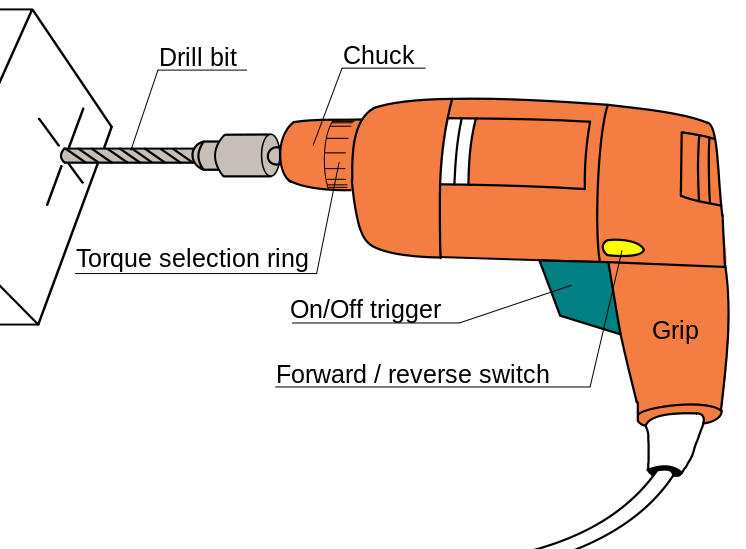

[figure not shown]

## Premises

- We live in a car dominated system
- Transport models are leverage points in the transport system
- 'Systemic' change is a long process and involves institutional change (Beddoe et al. 2009)
- Leverage points such as models can speed-up the transition
- Software for transport models is more accessible than ever

## Institutional structures I: Board

### Source: [Department for Transport](https://www.gov.uk/government/uploads/system/uploads/attachment_data/file/500776/dft-organisation-chart.pdf)

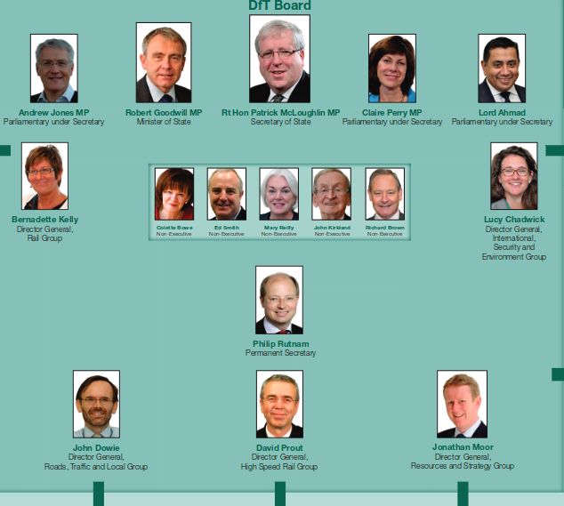

## Institutional structures II: Roads Traffic and Local Group

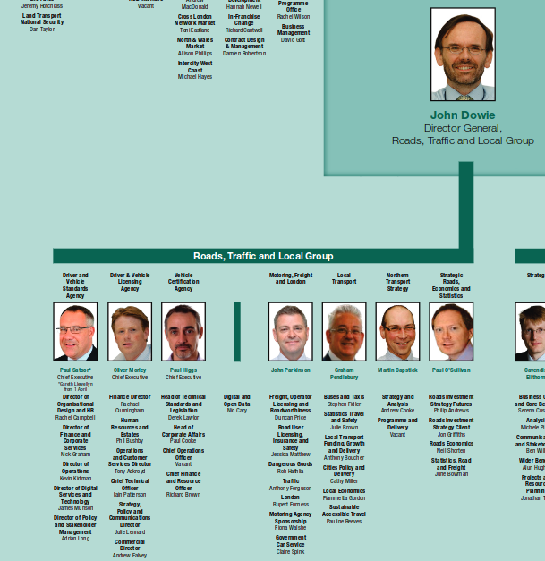

## Institutional structures III: Local Transport

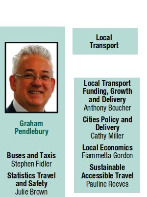

## Institutional structures

### A root cause of the 'problem'

[figure not shown]

## The origins of transport modelling

## Inspiration for this section

### Forecasting urban travel

- Book by Boyce and Williams (2015)

[figure not shown]

## Origins of Transport planning

### Credit: Crispin Cooper. See cardiff.ac.uk/sdna/

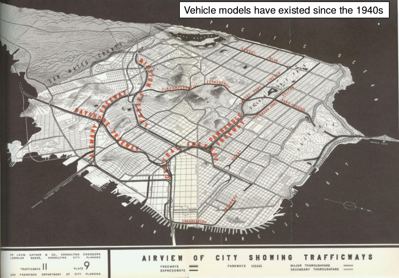

## The origins of modelling

- "urban travel forecasting was definitely 'where the action was' for young transportation engineers and planners entering the field in the 1960s" (Boyce and Williams 2015, 67).
- heavily restricted by computing power
- no consideration of walking or cycling

## Transport models vs cycling

## Transport planning tools: expensive…

[figure not shown]

## And potentially dangerous!

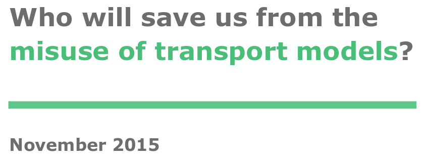

Source: [Who will save us from transport models](http://www.ctthink.com/publications.html) (Hollander 2015)

See also work by [Robert Bain](http://ibtta.org/sites/default/files/The%20Reasonableness%20of%20Traffic%20Forecasts.pdf)

## Tools for transport planning I

### Source: [Pixton.com](https://www.pixton.com/comic/xya3s212)

[figure not shown]

- Are black boxes

## Tools for transport planning II

### Source: [openclipart](https://openclipart.org/download/188748/manwithbighammer.svg)

[figure not shown]

- Tools are blunt

## Tools for transport planning III

### Source: By James Albert Bonsack (1859 – 1924), [Wikimedia](https://commons.wikimedia.org/w/index.php?curid=1267158)

[figure not shown]

- Are sometimes too complex!
- Implications for others

## An open source approach

## Open source in other sectors

[figure not shown]

- We can learn from 'early adopter' sectors

## Community buy-in

[figure not shown]

## Testing many tools

### Source: [Camcycle.org](https://www.camcycle.org.uk/blog/2015/10/23/milton-road-elizabeth-way-junction-proposals/)

[video not shown]

## Participatory planning

[figure not shown]

## Envisioning shifting travel patterns

### Source: Leeds Cycling Campaign

[figure not shown]

## Incorporation of new digital technologies

[figure not shown]

## Transport planning is somthing you *do*

### Source: Lovelace et al. (2016)

See http://pct.bike/london

[figure not shown]

## Summary table

| Keep | Replace | How |
| --- | --- | --- |
| Terminology | Inaccessible | Online tools |
| Equations | Proprietary ownership | Open source licences |
| Use of scenarios | Ageing software | New software |
|  | Narrow scenarios of future | Flexible models |
|  | Black boxes | Simple and open method |

## Get tooled up

- Learn to speak 'their' language
- Make use of web technologies: Google Maps, CycleStreets.net, CycleScape etc.
- The Propensity to Cycle Tool is an open source, online and accessible model
- Engage with transport models

## References

Lovelace, Robin. 2016. "Mapping out the future of cycling." Get Britain Cycling, 2016. P. 22 - 24. Available from [getbritaincycling.net](http://getbritaincycling.net/)

Beddoe, Rachael, Robert Costanza, Joshua Farley, Eric Garza, Jennifer Kent, Ida Kubiszewski, Luz Martinez, et al. 2009. “Overcoming Systemic Roadblocks to Sustainability: The Evolutionary Redesign of Worldviews, Institutions, and Technologies.” *Proceedings of the National Academy of Sciences* 106 (8): 2483–9. doi:10.1073/pnas.0812570106.

Boyce, David E., and Huw C. W. L. Williams. 2015. *Forecasting Urban Travel: Past, Present and Future*. Edward Elgar Publishing.

Lovelace, Robin, Anna Goodman, Rachel Aldred, Nikolai Berkoff, Ali Abbas, and James Woodcock. 2016. “The Propensity to Cycle Tool: An Open Source Online System for Sustainable Transport Planning.” *ArXiv:1509.04425 [Cs]*. http://arxiv.org/abs/1509.04425.